# Data processing for geospatial predictors

Anthony Stewart

### Point Data

Soil pedon locations contain multiple observations per pedon, one for each horizon.

```r
library(terra)
library(tidyterra)

wa_dat <- read.csv("SOIL CARBON/ANALYSIS/All_WA_horizons_spec_geoage.csv") |>
    dplyr::select(sample_ID, site, depth_cm, BD_g_cm3, carbon_perc,
        carbon_stock_g_cm2, x, y)
str(wa_dat)

wa_dat_pts <- vect(wa_dat, geom = c("x", "y"), crs = "EPSG:26910")
plot(wa_dat_pts)
```

### Raster and Vector data

We import and project geospatial data derived from digital elevation models (DEMs)

In particular, `geomorphons` is derived using **Whitebox Tools** which implements the algorithm from

*Jasiewicz, J., and Stepinski, T. F. (2013). Geomorphons — a pattern recognition approach to classification and mapping of landforms. Geomorphology, 182, 147-156.*

- The 10 types of geomorphons are given categorical letter codes

```r
catconv <- data.frame(id = 1:10, geomorphons = letters[1:10])

# Colville
col_hli <- rast("SOIL CARBON/SPATIAL LAYERS/SPATIAL_LAYERS_7_11_22/COL/col_HLI.tif") |>
    project("EPSG:26910")
col_geomorph <- rast("SOIL CARBON/SPATIAL LAYERS/SPATIAL_LAYERS_7_11_22/COL/col_geomorphons_11_23.tif")
col_geomorph_cat <- categories(col_geomorph, layer = 1, value = catconv) |>
    project("EPSG:26910")


# Mashel
mas_hli <- rast("SOIL CARBON/SPATIAL LAYERS/SPATIAL_LAYERS_7_11_22/MAS/mas_HLI.tif") |>
    project("EPSG:26910")
mas_geomorph <- rast("SOIL CARBON/SPATIAL LAYERS/SPATIAL_LAYERS_7_11_22/MAS/mas_geomorphons_11_23.tif") |>
    project("EPSG:26910")
mas_geomorph_cat <- categories(mas_geomorph, layer = 1, value = catconv) |>
    project("EPSG:26910")


# Hoh
hoh_hli <- rast("SOIL CARBON/SPATIAL LAYERS/SPATIAL_LAYERS_7_11_22/HOH/hoh_HLI.tif") |>
    project("EPSG:26910")
hoh_geomorph <- rast("SOIL CARBON/SPATIAL LAYERS/SPATIAL_LAYERS_7_11_22/HOH/hoh_geomorphons_11_23.tif")
hoh_geomorph_cat <- categories(hoh_geomorph, layer = 1, value = catconv) |>
    project("EPSG:26910")
```

We merge layers to make extracting geospatial predictors easier

The `merge_wip` refers to the **Wetland Intrinsic Potential** (WIP) tool and is derived from implementing the algorithm in

*Halabisky, Meghan, Dan Miller, Anthony J. Stewart, Amy Yahnke, Daniel Lorigan, Tate Brasel, and Ludmila Monika Moskal. “The Wetland Intrinsic Potential Tool: Mapping Wetland Intrinsic Potential through Machine Learning of Multi-Scale Remote Sensing Proxies of Wetland Indicators.” Hydrology and Earth System Sciences 27, no. 20 (October 20, 2023): 3687–99. https://doi.org/10.5194/hess-27-3687-2023.*

```r
# Merge Layers
geomorph_stack <- rast("SOIL CARBON/SPATIAL LAYERS/SPATIAL_LAYERS_7_11_22/All_WA/ALL_WA_geomorph_merge.tif")  #terra::merge(col_geomorph_cat, mas_geomorph_cat, hoh_geomorph_cat, filename = 'SOIL CARBON/SPATIAL LAYERS/SPATIAL_LAYERS_7_11_22/All_WA/ALL_WA_geomorph_merge.tif')
hli_stack <- rast("SOIL CARBON/SPATIAL LAYERS/SPATIAL_LAYERS_7_11_22/All_WA/ALL_WA_HLI_merge.tif")  #terra::merge(col_hli, mas_hli, hoh_hli, filename = 'SOIL CARBON/SPATIAL LAYERS/SPATIAL_LAYERS_7_11_22/All_WA/ALL_WA_HLI_merge.tif')

merge_wip <- rast("SOIL CARBON/SPATIAL LAYERS/SPATIAL_LAYERS_7_11_22/All_WA/ALL_WA_WIP_MERGE.tif")
```

Here is a map of the Hoh River Watershed WIP, where `0.0 = 0% Wetland or Upland` and `1.0 = 100% Wetland`

- The gradient captures hydrologic conditions across the landscape and derived mostly from topography metrics at different scales

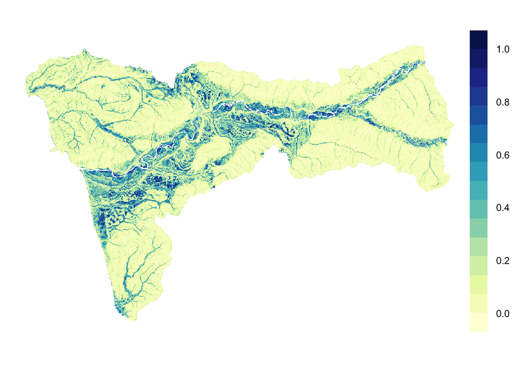

More geospatial predictors from across WA state. This includes precipitation and temperature from The PRISM Climate Group

*PRISM Climate Group, Oregon State University, https://prism.oregonstate.edu*

Spectral data are considered to approximate vegetation productivity and health. They are derived from Landsat median reflectance data collected over 2013-2022 and downloaded from Google Earth Engine.

Geology data on geologic age and lithology are downloaded from the WA Dept. of Natural Resoures

```r
# All WA layers
wa_state <- vect("SOIL CARBON/SPATIAL LAYERS/SPATIAL_LAYERS_7_11_22/All_WA/WA_State_Boundary/WA_State_Boundary.shp") |>
    project("EPSG:4326")

wa_precip <- rast("SOIL CARBON/SPATIAL LAYERS/SPATIAL_LAYERS_7_11_22/All_WA/ALL_WA_Precip.tif") |>
    terra::project("EPSG:26910")
wa_temp <- rast("SOIL CARBON/SPATIAL LAYERS/SPATIAL_LAYERS_7_11_22/All_WA/ALL_WA_Temp.tif") |>
    terra::project("EPSG:26910")

wa_geology <- vect("WA_Geo/ger_portal_surface_geology_100k/surface_geology_100k.gdb",
    layer = "geologic_unit_poly_100k") |>
    terra::project("EPSG:26910") |>
    tidyterra::select(LITHOLOGY, GEOLOGIC_AGE)

wa_spec1 <- rast("SOIL CARBON/SPATIAL LAYERS/SPATIAL_LAYERS_7_11_22/All_WA/WA_median_region/WA_median_regions-0000000000-0000000000.tif")
wa_spec2 <- rast("SOIL CARBON/SPATIAL LAYERS/SPATIAL_LAYERS_7_11_22/All_WA/WA_median_region/WA_median_regions-0000000000-0000019968.tif")  #
wa_spec3 <- rast("SOIL CARBON/SPATIAL LAYERS/SPATIAL_LAYERS_7_11_22/All_WA/WA_median_region/WA_median_regions-0000006656-0000006656.tif")  #

wa_spec_merge <- terra::merge(wa_spec1, wa_spec2, wa_spec3, filename = "SOIL CARBON/SPATIAL LAYERS/SPATIAL_LAYERS_7_11_22/All_WA/WA_median_GEE_spec_median_merge.tif",
    overwrite = T) |>
    project("EPSG:26910")
```

### Extraction

The locations of the pedon observations are used to extract all geospatial metrics.

```r
wa_geo_ext <- read.csv("SOIL CARBON/SPATIAL LAYERS/SPATIAL_LAYERS_7_11_22/All_WA/WA_geo_extract.csv")

wa_dat_pts_ext <- wa_dat_pts |>
    terra::extract(x = geomorph_stack, bind = TRUE, method = "simple") |>
    terra::extract(x = hli_stack, bind = TRUE, method = "simple") |>
    terra::extract(x = wa_precip, bind = TRUE, method = "simple") |>
    terra::extract(x = wa_temp, bind = TRUE, method = "simple") |>
    terra::extract(x = merge_wip, bind = TRUE, method = "simple") |>
    terra::extract(x = wa_spec_merge, bind = TRUE, method = "simple") |>
    tidyterra::rename(HLI = lyr.1, Precip = PRISM_ppt_30yr_normal_800mM4_annual_asc,
        Temp = PRISM_tmean_30yr_normal_800mM4_annual_asc, WIP = WET) |>
    tidyterra::select(-uncertainty) |>
    tidyterra::bind_spat_cols(wa_geo_ext[, c("LITHOLOGY", "GEOLOGIC_AGE")])
(values(wa_dat_pts_ext))
names(wa_dat_pts_ext)

write.csv(wa_dat_pts_ext, file = "SOIL CARBON/ANALYSIS/R/WA_SOC_controls/All_WA_horizons_spec_geoagelith.csv")
writeVector(wa_dat_pts_ext, file = "SOIL CARBON/SPATIAL LAYERS/SPATIAL_LAYERS_7_11_22/All_WA/All_WA_horizons_spec_geoagelith.gpkg",
    overwrite = T)
```